# Module 1: Programming Fundamentals

Author

Katie Dyck

Published

May 20, 2026

# 1 Introduction

This qmd file includes all material covered from the “Introduction to Programming” workshops. The material covered includes:

- **Workshop 1: *A Basic Introduction to R***
  - Variables
  - Functions
  - Debugging code
  - Data types
  - Data structures
  - Data frames and tibbles
  - Installing and loading package libraries
  - Best coding practices
- **Workshop 2: *Data Visualization***
  - `ggplot2` package
  - Setting plot aesthetics (`aes()`) and geoms (`geom()`)
- **Workshop 3: *Reproducible Research in Marine Science***
  - Linking RStudio to GitHub
- **Workshop 4: *Developers Toolbox and AI***
  - Using GitHub’s Copilot feature to help generate R code
  - Using Google Gemini and R `chattr` package to help generate R code
  - `if()` / `else()` / `if_else()` / `case_when()`
  - for loops
  - `purrr` package
  - How to write custom functions

# 2 Housekeeping

Purge the global environment with the command `rm(list = ls())`.

# 3 Load packages

Packages needed for this module are `tidyverse`, `palmerpenguins`, `purrr`, and `usethis`.

# 4 **Workshop 1: Introduction**

This workshop covered a basic introduction to coding in R.

```r
## ------ Getting Started ------ ####
# This section introduces us to R by using it as a simple calculator.

2 + 1
1:30
# 6 *
  # not complete - when you run this line, console asks you to unput a number after the asterisk

# 6 % 4  - doesn't work!
6 / 4



## ------ Variables and Assignment ------ ####
# This section focuses on understanding how data is stored in R and why that matters.

age <- 25
first_name <- 'Bill'

age
first_name

age + 1
age + age

# In R, you can’t use a number at the beginning of an object name and you can’t use some special symbols, including spaces.
# 01_age <- 25 # starts with a number
# !_age <- 25 # no special symbols
# age bob <- 25 # no spaces
Age <- 41 # cases matter

`age bob` <- 25 # no spaces, but with back ticks
# This is useful in some situations, however, it is better to use informative object names to make your code readable

# Run an algorithm:
25 + 15.1 + 20.25
x <- 30
25 + 15.1 + 20.25 + x



## ------ Functions ------ ####
# This section focuses on exploring built-in R functions

years_old <- 25.7
round(years_old)  # round up
floor(years_old)  # returns the largest integer not greater than elements of 'years_old'

years_old <- 25.765
round(years_old, digits = 2)

age <- 30
name <- "Katie"
paste(name, "is", age, "years old.", sep = " ")
paste(name, "is almost", age + 1, "years old.", sep = " ")



## ------ Debugging ------ ####
# Debugging is the process of finding and fixing errors in your code.

# Misconceptions
# variables don't work the same way as they do in spreadsheets

grade <- 55
total <- grade + 10
print(total)
grade <- 90
print(total)  # value of total in a spreadsheet would be 100, but here a variable holds the value it was assigned (65)
total <- grade + 10
print(total)

p <- 2
z <- 5
out <- p * z
print(out)

# debugging errors
# out <- p * a   # undefined variable 'a'
## > Error: object 'a' not found
out <- p * z

x <- 1
is.character(x)
is.integer(x)
is.numeric(x)
is.logical(x)

# my_quiz <- c("uno",
#              "dos",
#              "tres",
#              "cuatro"   # comma is missing!
#              "cinco")
# print(my_quis)   # spelling error
# str(my_quiz)
# len(my_quiz)   # len() not a function

my_quiz_fixed <- c("uno",
             "dos",
             "tres",
             "cuatro",
             "cinco")
print(my_quiz_fixed)
str(my_quiz_fixed)
length(my_quiz_fixed)



## ------ Data types ------ ####

my_numeric_variable <- 4.2
class(my_numeric_variable)
typeof(my_numeric_variable)
attributes(my_numeric_variable)
length(my_numeric_variable)



## ------ Data structures ------ ####

# A vector is a collection of elements that are most commonly of the type character, numeric, integer, logical.
y <- c(1,2,3)
class(y)
typeof(y)
z <- c("Sarah", "Tracy", "John")
class(z)
typeof(z)

# Values inside a list can be several different types.
x <- list(1, "A", TRUE)
x
class(x)
typeof(x)
length(x)
x[[2]]   # use square brackets to retrieve individual elements in a list



## ------ Data frames and tibbles ------ ####
# 2D or "rectangular" data files

my_dataframe <- data.frame(
  no = c(1,2,3),
  name = c("Tracey", "John", "Pete"),
  logical = c(TRUE, FALSE, TRUE)
)
my_dataframe
str(my_dataframe)

my_dataframe$no = as.factor(my_dataframe$no)
str(my_dataframe)



## ------ Packages and libraries ------ ####
# Using software that other people have written

# install.packages("ggplot2", "tidyr", "earthtones", "dplyr")
# library(ggplot2)



## ------ Coding best practices ------ ####

# To take a .csv file and turn it into a plot of the abundance of a single species:
#   1. read the .csv file dataset into R - read_csv()
#   2. view the dataset - e.g. str('dataset_name_here'), head('dataset_name_here'), glimpse('dataset_name_here')
#   3. identify which columns/variables you want to use to create the plot, and which plot type (geom_*()) you want to create
#   4. create your plot with ggplot() + geom_*()
```

# 5 **Workshop 2: Data Visualization**

This workshop covered different ways to visualize data in R. We used the dataset `mpg`, which contains information on the fuel economy of various car models from 1999 to 2008.

```r
str(mpg)
```

```
tibble [234 × 11] (S3: tbl_df/tbl/data.frame)
 $ manufacturer: chr [1:234] "audi" "audi" "audi" "audi" ...
 $ model       : chr [1:234] "a4" "a4" "a4" "a4" ...
 $ displ       : num [1:234] 1.8 1.8 2 2 2.8 2.8 3.1 1.8 1.8 2 ...
 $ year        : int [1:234] 1999 1999 2008 2008 1999 1999 2008 1999 1999 2008 ...
 $ cyl         : int [1:234] 4 4 4 4 6 6 6 4 4 4 ...
 $ trans       : chr [1:234] "auto(l5)" "manual(m5)" "manual(m6)" "auto(av)" ...
 $ drv         : chr [1:234] "f" "f" "f" "f" ...
 $ cty         : int [1:234] 18 21 20 21 16 18 18 18 16 20 ...
 $ hwy         : int [1:234] 29 29 31 30 26 26 27 26 25 28 ...
 $ fl          : chr [1:234] "p" "p" "p" "p" ...
 $ class       : chr [1:234] "compact" "compact" "compact" "compact" ...
```

```r
# "displ" = engine size (litres)
# "hwy" = car's fuel efficiency (mpg)
```

## 5.1 Create a `ggplot`

The `ggplot2` package library allows you to visualize different relationships that exist within one or multiple datasets. There are many different ways that plots can be customised when using this package.

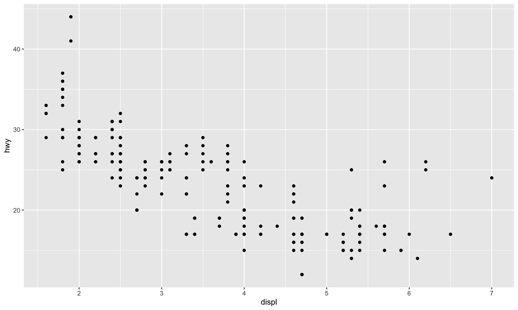

```r
ggplot(mpg, aes(displ, hwy)) +
    geom_point()
```

Setting an `alpha` value changes the transparency of data points and lines:

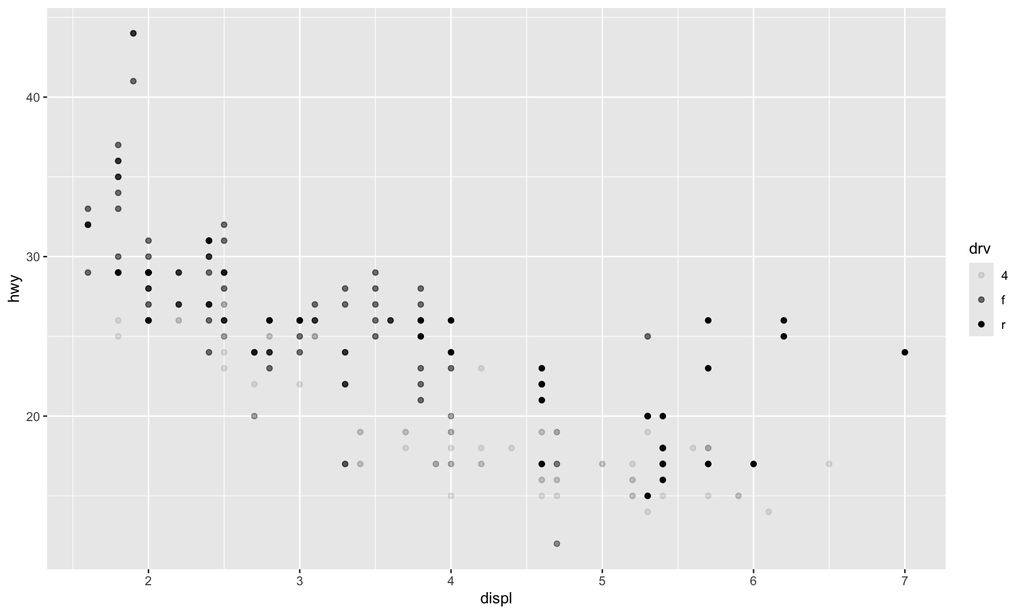

```r
# change transparency by class (alpha)
ggplot(mpg, aes(displ, hwy, alpha = drv)) +
    geom_point()
```

You can set a specific `color` for one (or multiple) variables:

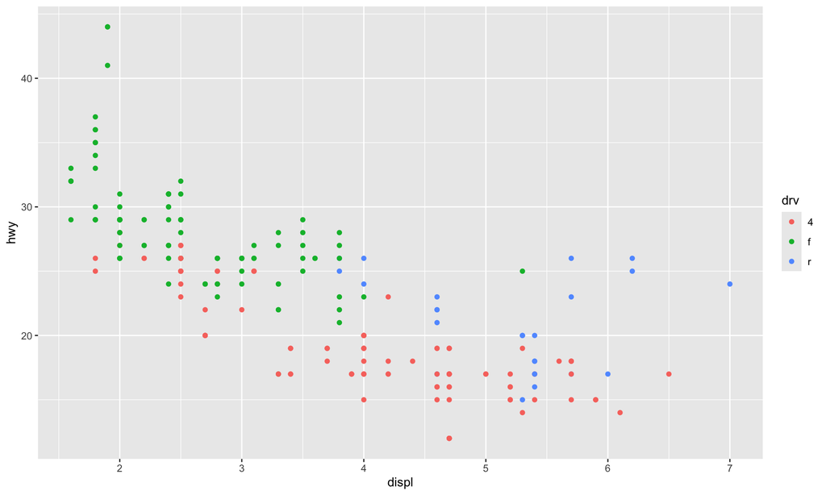

```r
# change colour by class
ggplot(mpg, aes(displ, hwy, color = drv)) +
    geom_point()
```

You change change the point `shape`:

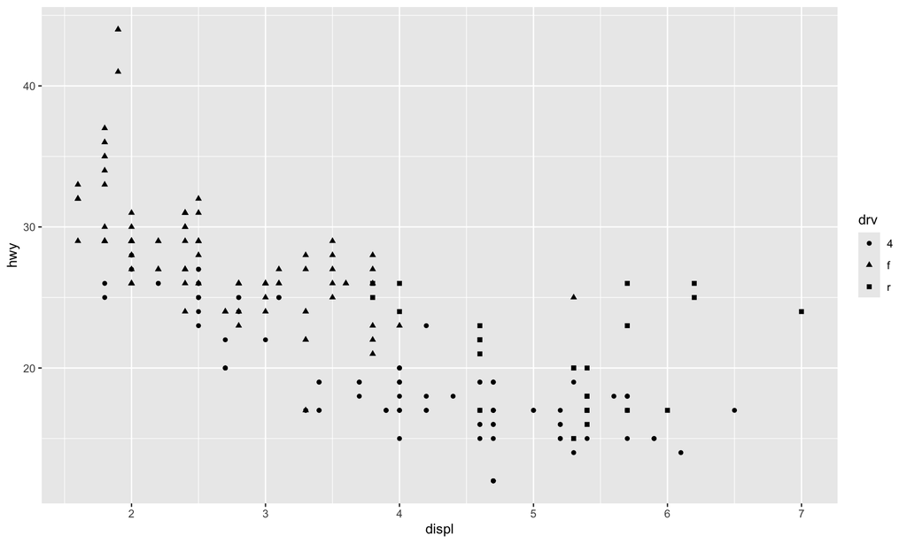

```r
# change point shape by class
ggplot(mpg, aes(displ, hwy, shape = drv)) +
    geom_point()
```

You can change the point `size`:

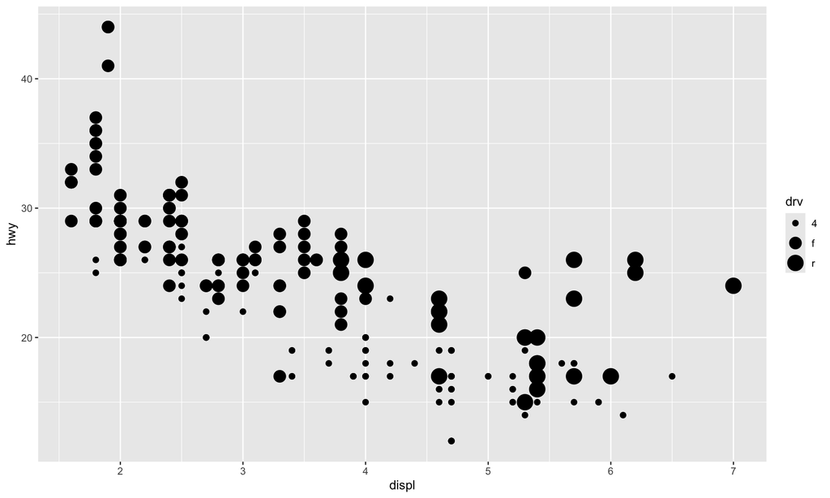

```r
# change point size by class
ggplot(mpg, aes(displ, hwy, size = drv)) +
    geom_point()
```

You can combine settings to change the appearance of variables and tell a story:

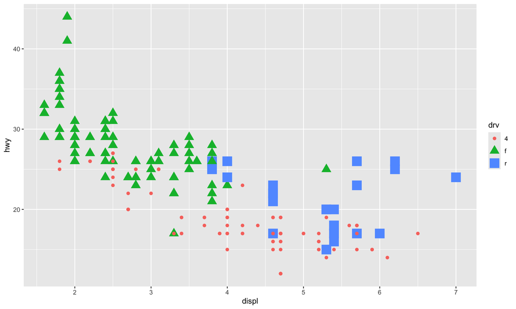

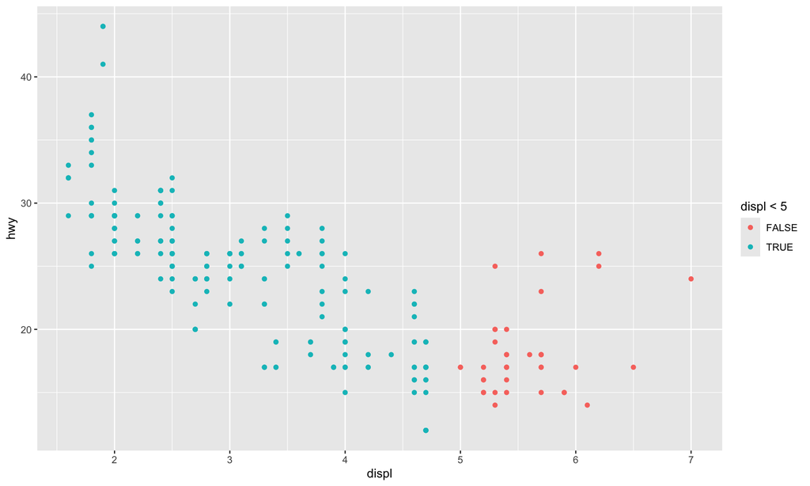

`facet_wrap()` and `facet_grid()` allow you to visualize the data in ways that make relationships between variables (particularly those that are discrete or factored) clearer.

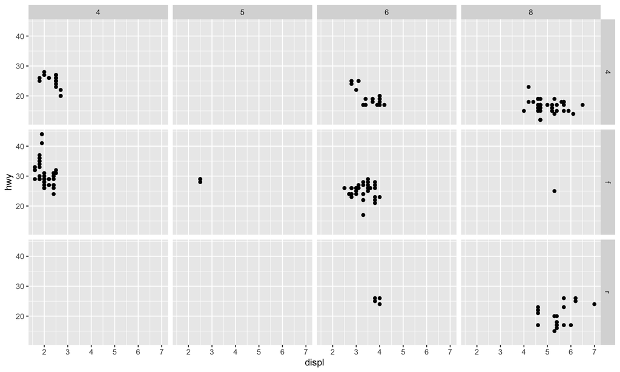

```r
# ggplot(mpg, aes(displ, hwy, colour = drv)) +
#     geom_jitter() +
#     facet_wrap(~ drv) +
#     theme(legend.position = "none",
#           plot.title = element_text(face = "bold")) +
#     labs(x = "Engine displacement (L)",
#          y = "Highway (mpg)")

# ggplot(mpg) +
#     geom_point(aes(displ, hwy)) +
#     facet_wrap(~ class, nrow = 2)

# facet_grid() is used with more than one variable
ggplot(mpg) +
    geom_point(aes(displ, hwy)) +
    facet_grid(drv ~ cyl)
```

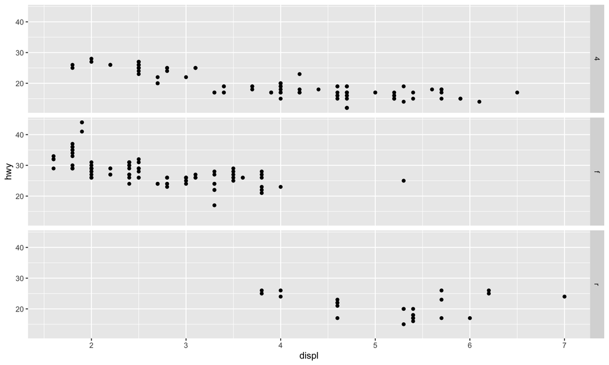

```r
# use a . if you don't want to facet in the rows or columns dimension
# ggplot(mpg) +
#     geom_point(aes(displ, hwy)) +
#     facet_grid(. ~ cyl)
ggplot(mpg) +
    geom_point(aes(displ, hwy)) +
    facet_grid(drv ~ .)
```

`geom_smooth()` makes it easier to visualize patterns in the data, particularly when there are many data points present.

- `loess` (Locally Estimated Scatterplot Smoothing) line - fits a smooth, localised regression line that bends to show non-linear patterns.

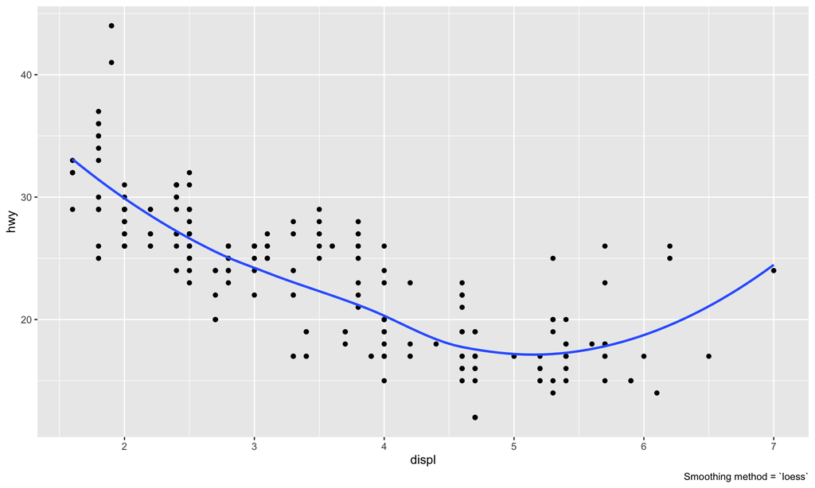

```r
ggplot(mpg, aes(displ, hwy)) +
    geom_point() +
    geom_smooth(se = FALSE) +   # method = "loess" (default)
    labs(caption = "Smoothing method = `loess`")
```

- `lm` (Linear Model) line - fits a single, straight linear regression line across the entire dataset.

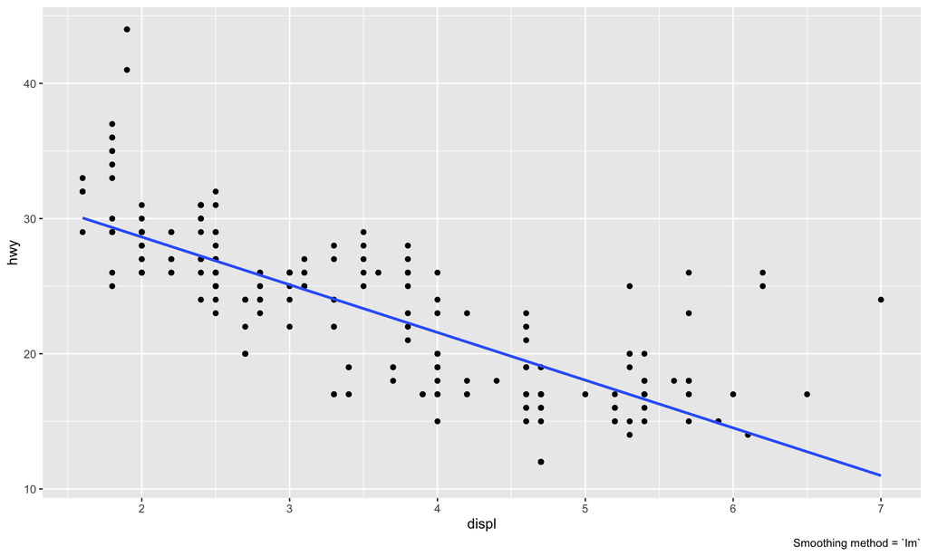

```r
ggplot(mpg, aes(displ, hwy)) +
    geom_point() +
    geom_smooth(method = "lm", se = FALSE) +
    labs(caption = "Smoothing method = `lm`")
```

`geom_smooth()` can accept a variable for the `linetype` argument, which allows you to visualize how the data changes for different values of a specific variable. The graph below shows how highway miles per gallon changes with engine displacement (in litres) between different types of drive train (4-wheel drive, front-wheel drive, and rear-wheel drive).

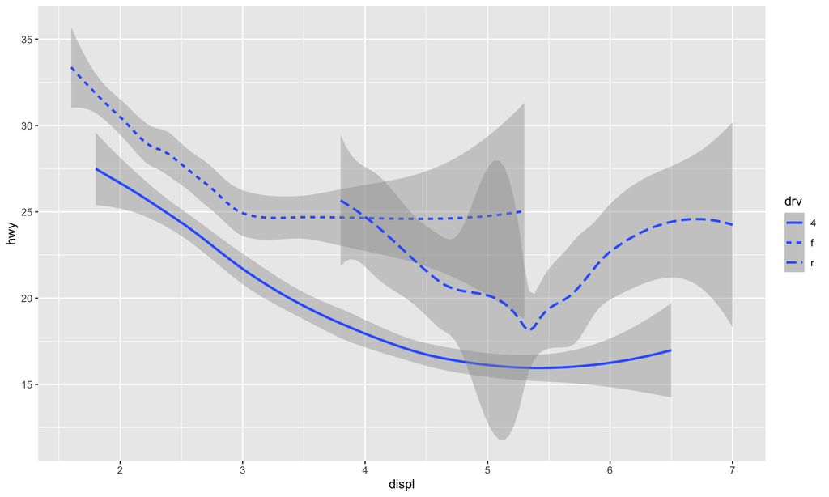

```r
ggplot(mpg) +
    geom_smooth(aes(displ, hwy, linetype = drv))
```

You can create plots with multiple geoms to show relationships between different variables in the data:

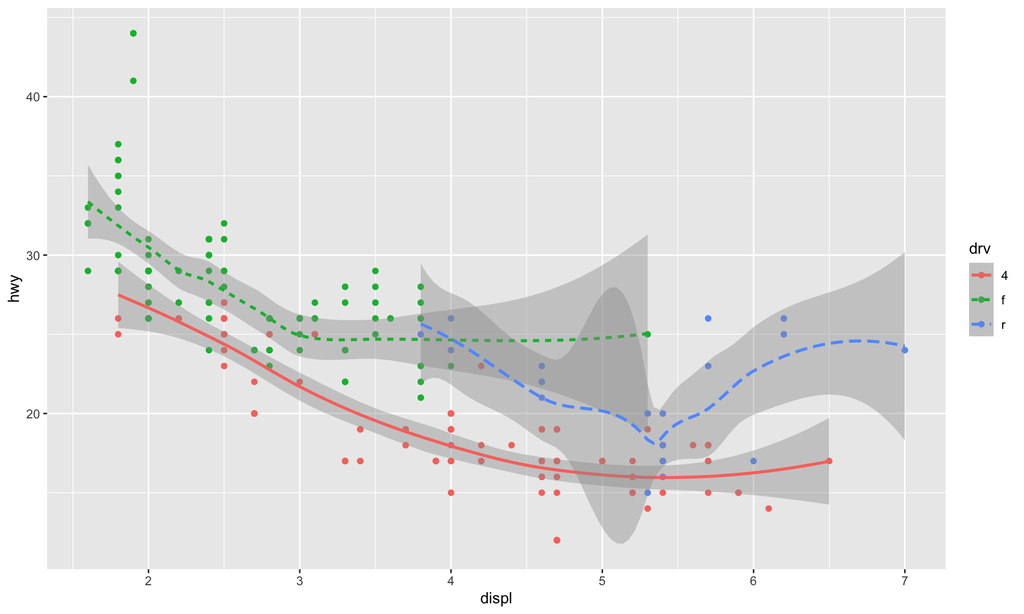

```r
ggplot(mpg) +
    geom_point(aes(displ, hwy, colour = drv)) +
    geom_smooth(aes(displ, hwy, colour = drv, linetype = drv))
```

You can use mapping in specific layers to enable the display of different aesthetics in different layers. In the second plot below, the aesthetics of the `geom_smooth()` layer have been filtered to only include subcompact cars.

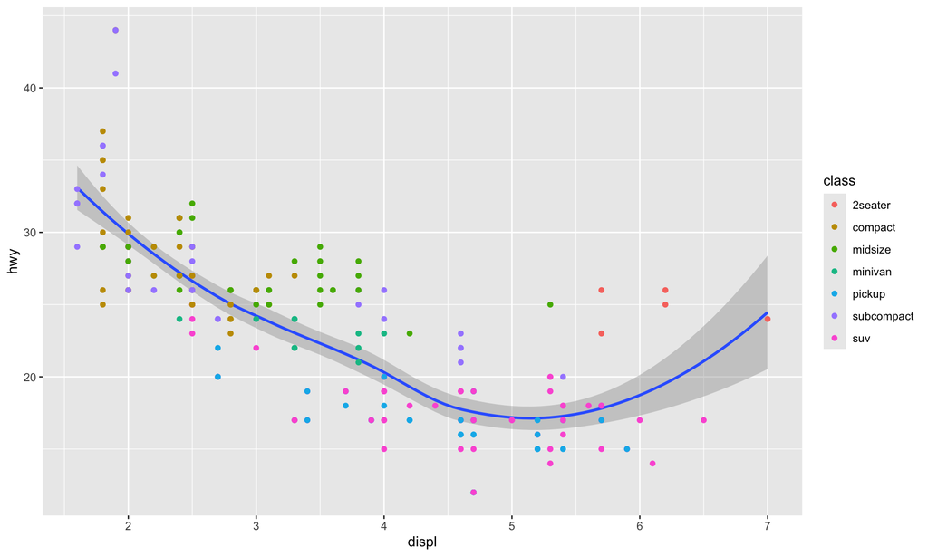

```r
ggplot(mpg, aes(displ, hwy)) +
    geom_smooth() +
    geom_point(aes(colour = class))
```

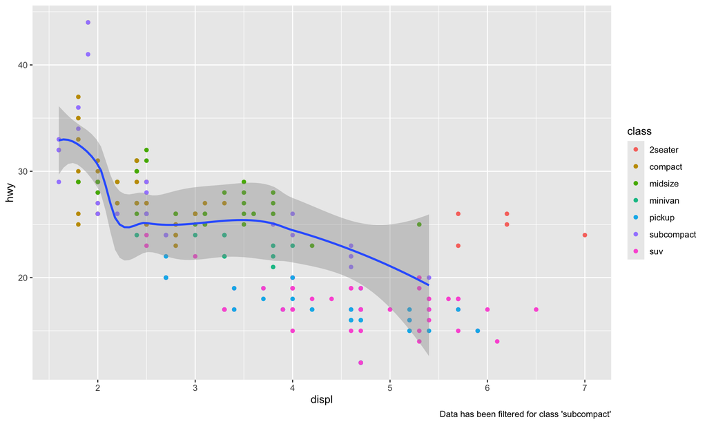

```r
ggplot(mpg, aes(displ, hwy)) +
    geom_point(aes(colour = class)) +
    geom_smooth(data = filter(mpg, class == "subcompact")) +
    labs(caption = "Data has been filtered for class 'subcompact'")
```

## 5.2 Transformations and Stats

The `diamonds` dataset (from the ggplot2 package) contains information on over 50,000 cut diamonds.

```r
str(diamonds)
```

```
tibble [53,940 × 10] (S3: tbl_df/tbl/data.frame)
 $ carat  : num [1:53940] 0.23 0.21 0.23 0.29 0.31 0.24 0.24 0.26 0.22 0.23 ...
 $ cut    : Ord.factor w/ 5 levels "Fair"<"Good"<..: 5 4 2 4 2 3 3 3 1 3 ...
 $ color  : Ord.factor w/ 7 levels "D"<"E"<"F"<"G"<..: 2 2 2 6 7 7 6 5 2 5 ...
 $ clarity: Ord.factor w/ 8 levels "I1"<"SI2"<"SI1"<..: 2 3 5 4 2 6 7 3 4 5 ...
 $ depth  : num [1:53940] 61.5 59.8 56.9 62.4 63.3 62.8 62.3 61.9 65.1 59.4 ...
 $ table  : num [1:53940] 55 61 65 58 58 57 57 55 61 61 ...
 $ price  : int [1:53940] 326 326 327 334 335 336 336 337 337 338 ...
 $ x      : num [1:53940] 3.95 3.89 4.05 4.2 4.34 3.94 3.95 4.07 3.87 4 ...
 $ y      : num [1:53940] 3.98 3.84 4.07 4.23 4.35 3.96 3.98 4.11 3.78 4.05 ...
 $ z      : num [1:53940] 2.43 2.31 2.31 2.63 2.75 2.48 2.47 2.53 2.49 2.39 ...
```

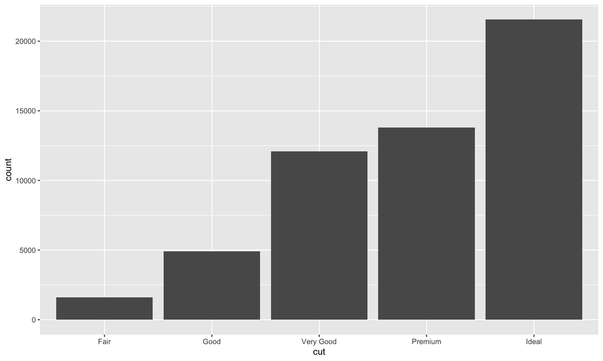

```r
ggplot(diamonds) +
  geom_bar(aes(x = cut))
```

- **bar charts**, **histograms**, and **frequency polygrams** “bin” data and then plot bin counts (the number of data points that fall in each bin).
- **smoothers** fit a model to the data and then plot predictions from the model.
- **boxplots** compute a summary of the distribution and then display a specially formatted box.

`geoms` and `stats` can generally be used interchangeably.

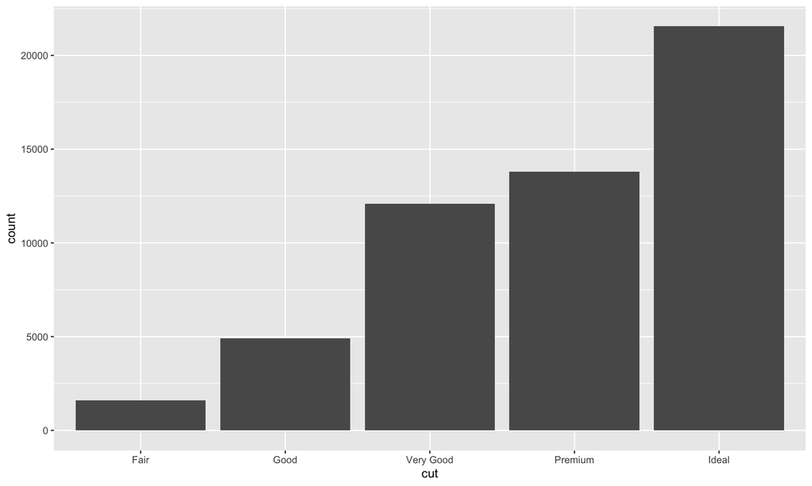

```r
ggplot(diamonds) +
    stat_count(mapping = aes(x = cut))
```

The tibble below contains the frequency of each diamond `cut` that appears in the dataset. We can use this table with the `stat` argument to override the default mapping.

```r
demo <- tribble(
    ~cut, ~freq,
    "Fair", 1610,
    "Good", 4906,
    "Very Good", 12082,
    "Premium", 13791,
    "Ideal", 21551
)
demo
```

```
# A tibble: 5 × 2
  cut        freq
  <chr>     <dbl>
1 Fair       1610
2 Good       4906
3 Very Good 12082
4 Premium   13791
5 Ideal     21551
```

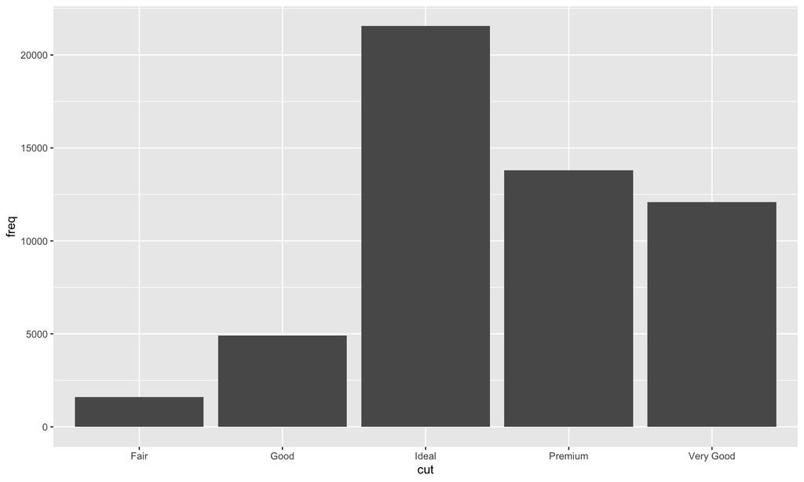

```r
ggplot(demo) +
    geom_bar(aes(x = cut, y = freq), stat = "identity")
```